# Intro to Statistial and Data Sciences

Last updated on 2017-02-12

## Lec01 - Mon 2/13: Introduction

## Course Title

- In catalog: Introduction to Statistical Sciences
- New: Introduction to Statistical **and Data** Sciences

## What is Data Science?

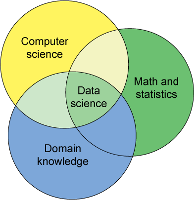

## Data Science

- Example domains: biology, economics, physics, sociology, etc.
- So why the title switch?

## Dialogue with Student

[figure not shown]

## Course Objective #1

Have students engage in the data/science research pipeline in as faithful a manner as possible while maintaining a level [suitable for novices](http://arxiv.org/abs/1507.05346).

- Cobb: Minimizing prerequisites to research
- Not necessarily publishing in top journals, but **answering scientific questions with data**.
- Difficult to do research without understanding stats, however

## Data/Science Research Pipeline

We will, as best we can, perform all this:

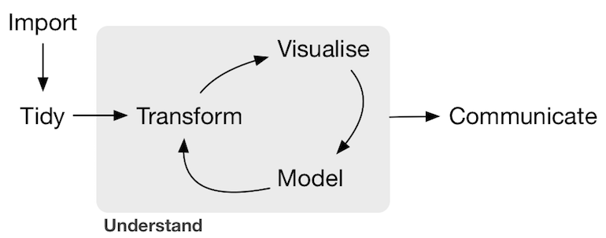

## Data/Science Research Pipeline

And not just this, as in many previous intro stats courses:

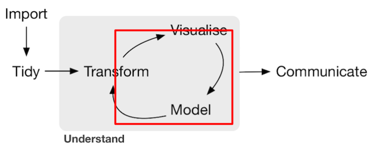

## Course Objective #2

Foster a conceptual understanding of statistical topics and methods using [simulation/resampling](https://www.amstat.org/education/pdfs/ResamplingUndergradCurriculum.pdf) and real data whenever possible, rather than mathematical formulae.

- Whenever we can, use real data
- Example data set: nycflights13
- There are two "engines" that can make statistics "work"
  - Mathematics: formulas, approximations, etc
  - Computers: simulations, random number generation

## The "Engine" of Statistics

In this course, computers and not math will be the "engine". What does this mean?

- Less of this:

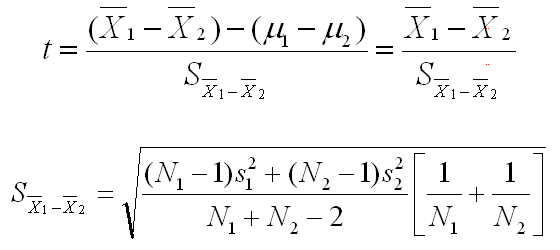

- But more of this:

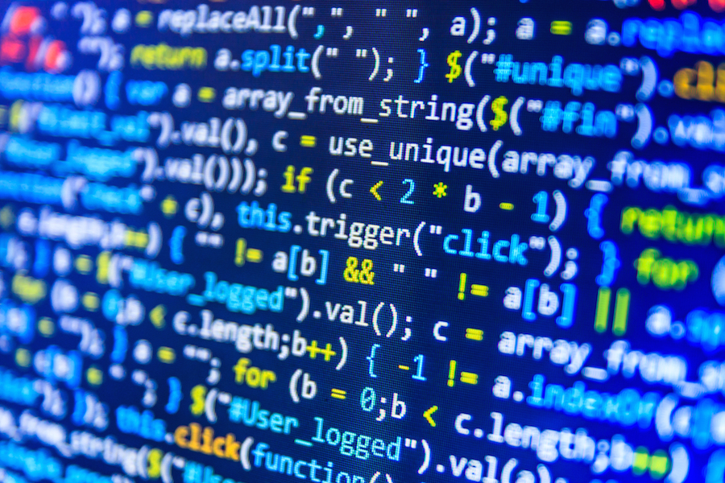

## Programming/Coding

- Previous programming/coding experience **is not a prerequisite to this course**
- This course is not an explicit course on programming, coding, nor computer science. But we will use some elements.
- Also you will be exposed to basic **algorithmic thinking and computational logic**
- Learning R is like learning a foreign language: its really hard at first!

## Two Simple Rules of Learning Code

- Computers are stupid!
- When learning, take existing code that works, and tweak it!

## Course Objective #3

Blur the traditional lecture/lab dichotomy of introductory statistics courses by incorporating more [computational and algorithmic thinking](http://www.stat.berkeley.edu/~statcur/Preprints/ComputingCurric3.pdf) into the syllabus.

- Completely separate lecture and labs is a legacy of a time before

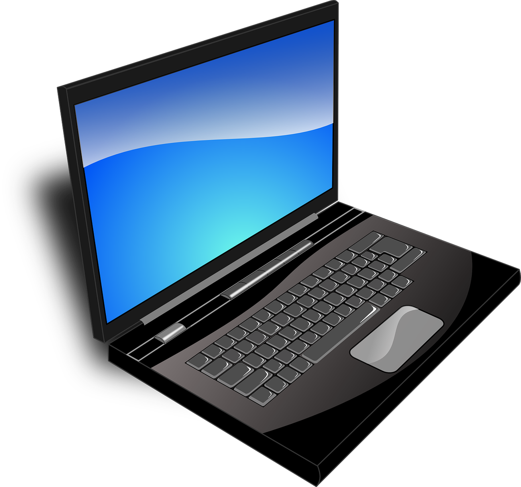

## RStudio Server

- Not all laptops are created equal: operating system, processing power, age
- RStudio Server: cloud-based version of RStudio where all processing is done on Middlebury servers
- [`go/rstudio/`](https://rstudio.middlebury.edu/) (on campus or via VPN)

## Course Objective #5

Develop [statistical literacy](https://en.wikipedia.org/wiki/Statistical_literacy) by, among other ways, tying in the curriculum to current events, demonstrating the importance statistics plays in society.

- H.G. Wells (paraphrased): "Statistical thinking will one day be as necessary for efficient citizenship as the ability to read and write."
- Me: "Sure, it's easy to lie with statistics. But it's also hard to tell the truth without them."

## Final Project

- Capstone experience to align this topics and principles of this course with how research and learning is done in practice.
- Work on interpersonal and collaborative skills. No textbook on that!

## Lecture Format

Either

- **Lab format**: With laptop
  - You sit in groups of 4
  - I'll talk for 10-15 minutes before you work on learning checks
- **Chalk talk**: Old-school
  - Keep desk in rows
  - More traditional lecture format

## Let's Build our Toolbox

[figure not shown]

## R, RStudio, and DataCamp

- R: Software behind the scenes i.e. **the engine**
- RStudio: Intergrated development environment i.e. **the interface**
- DataCamp: Browser-based learning tool i.e. **the driver's ed teacher**

## Analogy

R

RStudio

DataCamp

[figure not shown]

[figure not shown]

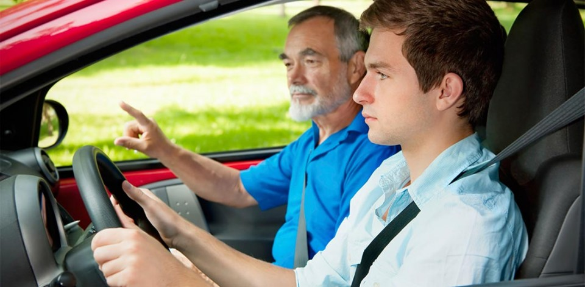

## Test Drive RStudio

- Login to [`go/rstudio/`](https://rstudio.middlebury.edu/auth-sign-in) with your Midd account
- If you don't have access, raise your hand. (Username: guest1, password: rstudioguest)
- In RStudio menu bar -> File -> New File -> R Script

## The Four Panels

1. Console: Crunch numbers in R
2. Files, Packages, Help: See your files, install packages, help files
3. Editor: Where you'll write code and save it
4. Environment: Your workspace

## Important: Console

- This is where you run/execute commands
- The ">" is the prompt. It means R is ready to receive commands
- If you don’t see a ">" and want to restart, press ESC.

## Switching Gears

Now we will use R via DataCamp instead of via RStudio, but just for driver's ed. Two panels exist in both:

1. Editor panel: Where you write code
2. Console panel: Where you will execute code